# Clase 10.5. Aplicacion ARIMA(p, d, q) y ARMA(p, q) V2

Benjamin Oliva & Omar Alfaro-Rivera

02/10/2021

# Importamos Datos:

Los datos importados son:

- Pax_Nal: Pasajeros (Salidas) en vuelos nacionales
- Pax_Int: Pasajeros (Salidas) en vuelos internacionales
- Vue_Nal: Vuelos u operaciones (Salidas) en vuelos nacionales
- Vue_Int: Vuelos u operaciones (Salidas) en vuelos internacionales
- Pax_Metro: Pasajeros transportados (Millones) en el SCM
- D_Sep2017: Dummy que toma el valor de 1 en septiembre de 2017
- D_Oct2017: Dummy que toma el valor de 1 en octubre de 2017
- D_Feb2020: Dummy que toma el valor de 1 en febrero de 2020
- D_Mar2020: Dummy que toma el valor de 1 en marzo de 2020
- D_Abr2020: Dummy que toma el valor de 1 en abril de 2020
- D_May2020: Dummy que toma el valor de 1 en mayo de 2020
- D_Jun2020: Dummy que toma el valor de 1 en junio de 2020
- D_Jul2020: Dummy que toma el valor de 1 en julio de 2020
- D_Ene2021: Dummy que toma el valor de 1 en enero de 2021
- D_Mar2021: Dummy que toma el valor de 1 en marzo de 2021
- D_Ene: Dummy que toma el valor de 1 en todos los eneros
- D_Dic: Dummy que toma el valor de 1 en todos los diciembres

Fuente: INEGI, https://www.inegi.org.mx/app/indicadores/?tm=0&t=1090

```r
Datos <- read_excel("Base_Transporte_ARIMA.xlsx", sheet = "Datos", col_names = TRUE)

head(Datos)
```

```
## # A tibble: 6 × 22
##   Periodo             Pax_Nal Pax_Int Vue_Nal Vue_Int Pax_Metro D_Sep2…¹ D_Oct…²
##   <dttm>                <dbl>   <dbl>   <dbl>   <dbl>     <dbl>    <dbl>   <dbl>
## 1 2000-01-01 00:00:00 1378244  672734   30290    7812      112.        0       0
## 2 2000-02-01 00:00:00 1318075  649382   28291    7440      112.        0       0
## 3 2000-03-01 00:00:00 1476646  750587   31031    8036      121.        0       0
## 4 2000-04-01 00:00:00 1426550  718826   29896    7886      106.        0       0
## 5 2000-05-01 00:00:00 1529293  663015   31382    7498      118.        0       0
## 6 2000-06-01 00:00:00 1427266  633091   30514    7351      118.        0       0
## # … with 14 more variables: D_Feb2020 <dbl>, D_Mar2020 <dbl>, D_Abr2020 <dbl>,
## #   D_May2020 <dbl>, D_Jun2020 <dbl>, D_Jul2020 <dbl>, D_Ene2021 <dbl>,
## #   D_Mar2021 <dbl>, D_Ene <dbl>, D_Feb <dbl>, D_Jul <dbl>, D_Dic <dbl>,
## #   D_Ene2022 <dbl>, D_Feb2022 <dbl>, and abbreviated variable names
## #   ¹D_Sep2017, ²D_Oct2017
```

# Funciones que extrae y grafica las raices del polinomio caracteristico

```r
source("arroots.R")
source("maroots.R")
source("plot.armaroots.R")
```

# Conversion a series de tiempo:

```r
Pax_Nal <- ts(Datos$Pax_Nal,
              start = c(2000, 1),
              freq = 12)

LPax_Nal <- ts(log(Datos$Pax_Nal),
               start = c(2000, 1),
               freq = 12)

DLPax_Nal <- ts(log(Datos$Pax_Nal) - lag(log(Datos$Pax_Nal), k = 1),
                start = c(2000, 1),
                freq = 12)

DLPax_Nal_S <- diff(DLPax_Nal, 12)

D_Feb2020   <- ts(Datos$D_Feb2020,
                start = c(2000, 1),
                freq = 12)

D_Mar2020   <- ts(Datos$D_Mar2020,
                start = c(2000, 1),
                freq = 12)

D_Abr2020   <- ts(Datos$D_Abr2020,
                start = c(2000, 1),
                freq = 12)

D_May2020   <- ts(Datos$D_May2020,
                start = c(2000, 1),
                freq = 12)

D_Jun2020   <- ts(Datos$D_Jun2020,
                start = c(2000, 1),
                freq = 12)

D_Jul2020 <- ts(Datos$D_Jul2020,
                start = c(2000, 1),
                freq = 12)

D_Ene2021 <- ts(Datos$D_Ene2021,
                start = c(2000, 1),
                freq = 12)

D_Mar2021 <- ts(Datos$D_Mar2021,
                start = c(2000, 1),
                freq = 12)

D_Ene <- ts(Datos$D_Ene,
            start = c(2000, 1),
            freq = 12)

D_Feb <- ts(Datos$D_Feb,
            start = c(2000, 1),
            freq = 12)

D_Jul <- ts(Datos$D_Jul,
            start = c(2000, 1),
            freq = 12)

D_Dic <- ts(Datos$D_Dic,
            start = c(2000, 1),
            freq = 12)
```

# Graficas:

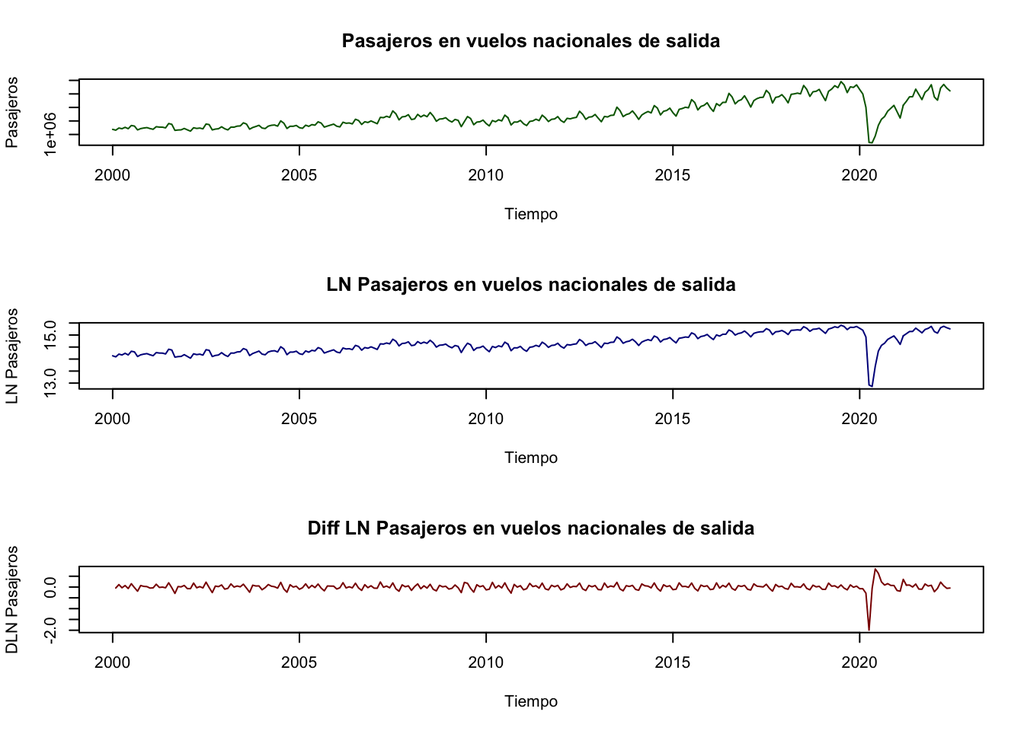

# Visualizar estacionalidad

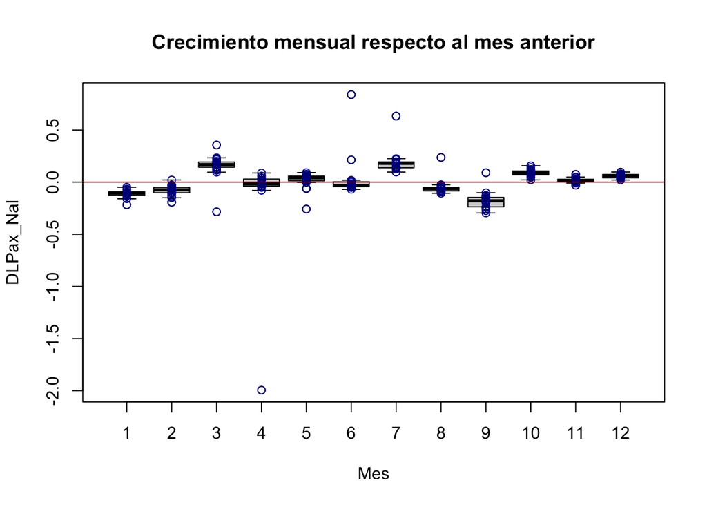

```r
boxplot(DLPax_Nal ~ month(Datos$Periodo),
        xlab= "Mes",
        main = "Crecimiento mensual respecto al mes anterior")
points(DLPax_Nal ~ month(Datos$Periodo), col = "darkblue")
abline(h = 0, col = "darkred")
```

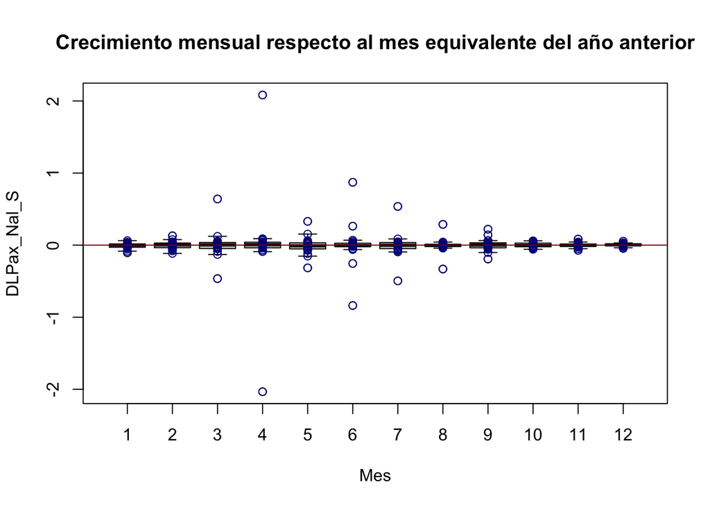

```r
boxplot(DLPax_Nal_S ~ month(Datos$Periodo[-c(1:12)]),
        xlab= "Mes",
        main = "Crecimiento mensual respecto al mes equivalente del año anterior")
points(DLPax_Nal_S ~ month(Datos$Periodo)[-c(1:12)], col = "darkblue")
abline(h = 0, col = "darkred")
```

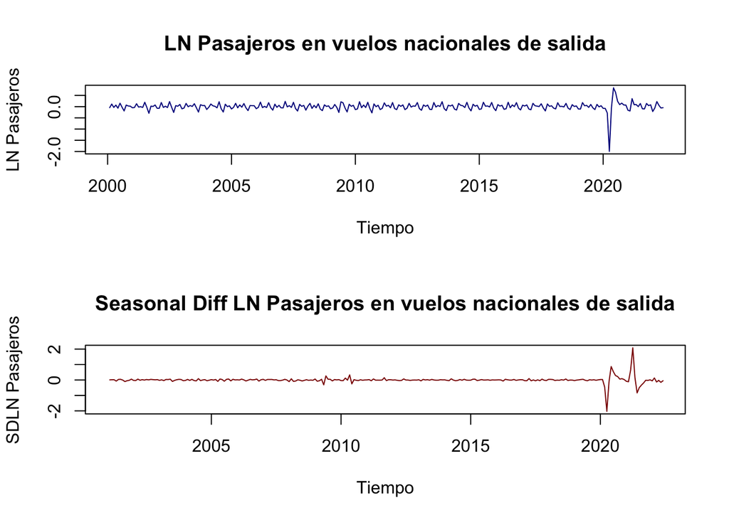

```r
par(mfrow=c(2,1))

plot(DLPax_Nal, xlab = "Tiempo", ylab = "LN Pasajeros",
     main = "LN Pasajeros en vuelos nacionales de salida",
     col = "darkblue")


plot(diff(DLPax_Nal,12), xlab = "Tiempo",  ylab = "SDLN Pasajeros",
     main = "Seasonal Diff LN Pasajeros en vuelos nacionales de salida",
     col = "darkred")
```

```r
par(mfrow=c(1,1))
```

# Funciones que determinan el rezago optimo (que minimiza el criterio de Akaike)

```r
source("Lag_Opt_ARIMA_Exog.R")
source("Lag_Opt_SARIMA_Exog.R")
```

# ARIMA Optimo

```r
dumm_ARIMA = cbind(D_Ene, D_Feb, D_Jul, D_Dic, D_Mar2020, D_Abr2020, D_Jun2020, D_Jul2020, D_Mar2021)

Lag_Opt_ARIMA_Exog( p_max = 6, q_max = 6,
                    X_t = DLPax_Nal,
                    Ex = 1,
                    Z_t = dumm_ARIMA )
```

```
##       Rezago p Rezago q       AIC Optimo
##  [1,]        1        1 -535.8678      0
##  [2,]        1        2 -535.9648      0
##  [3,]        1        3 -546.3264      0
##  [4,]        1        4 -565.4627      0
##  [5,]        1        5 -571.4528      0
##  [6,]        1        6 -581.4001      0
##  [7,]        2        1 -536.3790      0
##  [8,]        2        2 -543.7421      0
##  [9,]        2        3 -594.8421      0
## [10,]        2        4 -584.7638      0
## [11,]        2        5 -582.8908      0
## [12,]        2        6 -586.1809      0
## [13,]        3        1 -514.2042      0
## [14,]        3        2 -541.7628      0
```

[output cut: 22 more lines]

```r
ARIMA_Ex_DLPax_Nal <- arima( DLPax_Nal, c(6,0,6),
                             xreg = dumm_ARIMA,
                             method = "ML" )
ARIMA_Ex_DLPax_Nal
```

```
##
## Call:
## arima(x = DLPax_Nal, order = c(6, 0, 6), xreg = dumm_ARIMA, method = "ML")
##
## Coefficients:
##          ar1      ar2      ar3      ar4     ar5      ar6      ma1      ma2
##       0.0033  -0.0024  -0.0004  -0.0012  0.0064  -0.9970  -0.0553  -0.0687
## s.e.  0.0050   0.0041   0.0071   0.0040  0.0044   0.0029   0.0358   0.0323
##           ma3      ma4      ma5     ma6  intercept    D_Ene    D_Feb   D_Jul
##       -0.0869  -0.0183  -0.0538  0.9747     0.0195  -0.1676  -0.1675  0.1889
## s.e.   0.0313   0.0342   0.0348  0.0391     0.0041   0.0919   0.0174  0.0910
##         D_Dic  D_Mar2020  D_Abr2020  D_Jun2020  D_Jul2020  D_Mar2021
##       -0.0001    -0.4713    -1.9651     0.9067     0.5019     0.1764
## s.e.   0.0178     0.0489     0.0496     0.0542     0.0528     0.0500
##
## sigma^2 estimated as 0.002454:  log likelihood = 414.67,  aic = -783.34
```

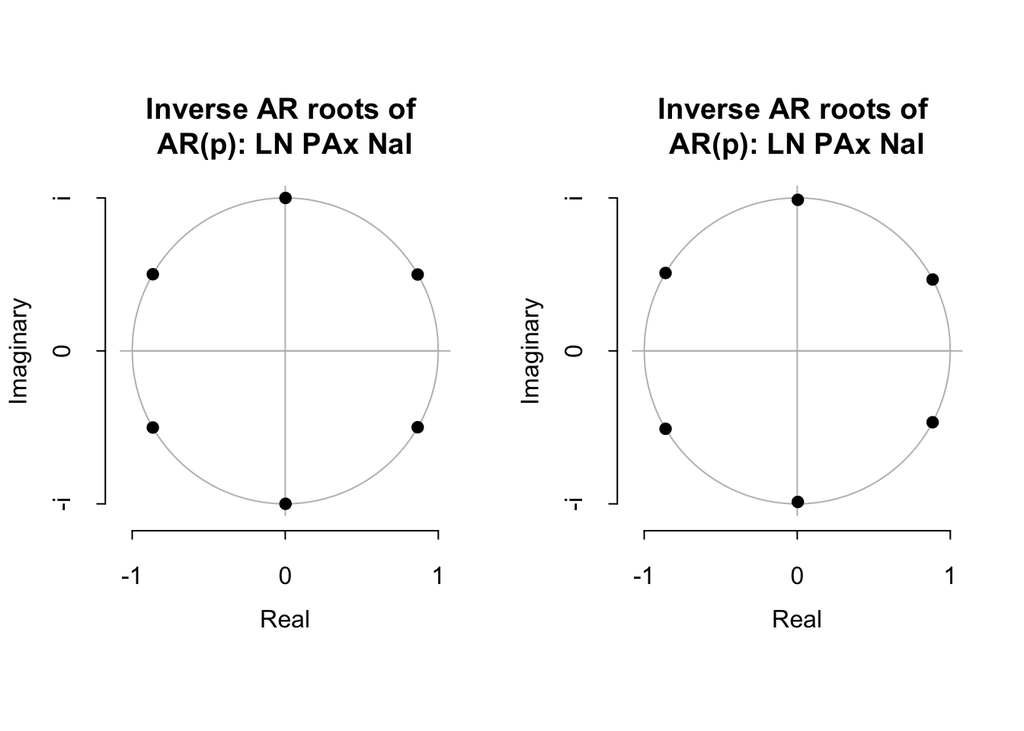

```r
par(mfrow=c(1,2))
plot.armaroots(arroots(ARIMA_Ex_DLPax_Nal),
               main="Inverse AR roots of \nAR(p): LN PAx Nal")
plot.armaroots(maroots(ARIMA_Ex_DLPax_Nal),
               main="Inverse AR roots of \nAR(p): LN PAx Nal")
```

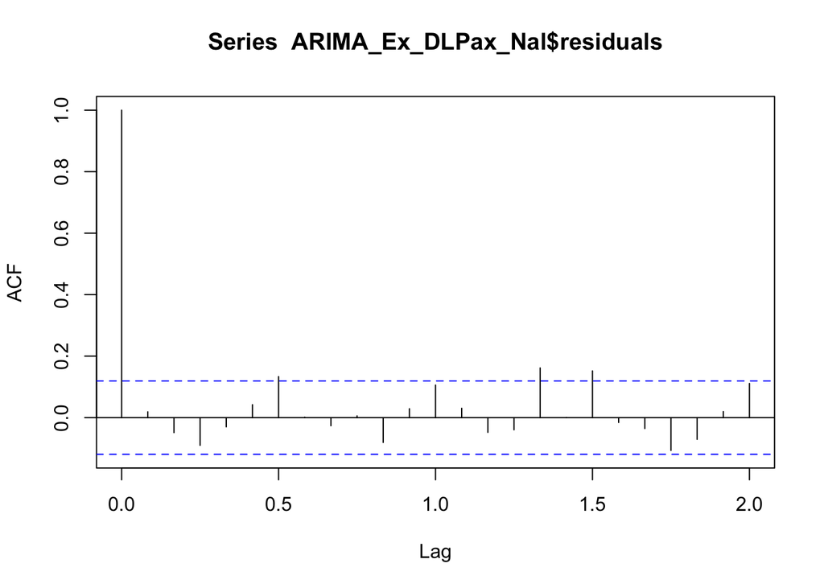

```r
par(mfrow=c(1,1))
acf(ARIMA_Ex_DLPax_Nal$residuals, na.action = na.pass)
```

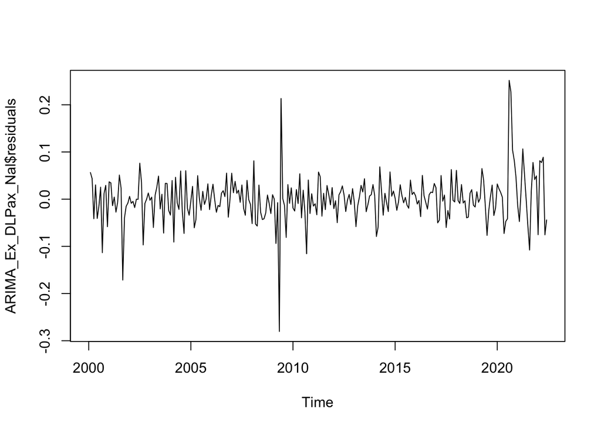

```r
plot(ARIMA_Ex_DLPax_Nal$residuals)
```

# SARIMA optimo

```r
dumm_SARIMA <-cbind(D_Mar2020[-c(1:12)], D_Abr2020[-c(1:12)], D_Jun2020[-c(1:12)], D_Jul2020[-c(1:12)], D_Mar2021[-c(1:12)])

Lag_Opt_SARIMA_Exog(p_max = 4, q_max = 4,
                    P_max = 0, Q_max = 2,
                   X_t = DLPax_Nal_S,
                   Ex = 0)
```

```
##       Rezago p Rezago q Rezago P Rezago Q        AIC Optimo
##  [1,]        1        1        0        0  -93.43083      0
##  [2,]        1        1        0        1 -248.46863      0
##  [3,]        1        1        0        2 -248.18173      0
##  [4,]        1        2        0        0 -128.26154      0
##  [5,]        1        2        0        1 -275.39902      1
##  [6,]        1        2        0        2 -274.13716      0
##  [7,]        1        3        0        0 -127.98598      0
##  [8,]        1        3        0        1 -274.08537      0
##  [9,]        1        3        0        2 -272.71649      0
## [10,]        1        4        0        0 -126.17206      0
## [11,]        1        4        0        1 -272.99352      0
## [12,]        1        4        0        2 -271.84495      0
## [13,]        2        1        0        0 -107.81850      0
## [14,]        2        1        0        1 -263.38167      0
```

[output cut: 34 more lines]

```r
Lag_Opt_SARIMA_Exog(p_max = 4, q_max = 4,
                    P_max = 0, Q_max = 2,
                    X_t = DLPax_Nal_S,
                    Ex = 1,
                    Z_t = dumm_SARIMA)
```

```
##       Rezago p Rezago q Rezago P Rezago Q       AIC Optimo
##  [1,]        1        1        0        0 -227.9300      0
##  [2,]        1        1        0        1 -313.3905      0
##  [3,]        1        1        0        2 -325.5121      0
##  [4,]        1        2        0        0 -253.3598      0
##  [5,]        1        2        0        1 -332.8424      0
##  [6,]        1        2        0        2 -341.5533      0
##  [7,]        1        3        0        0 -252.2434      0
##  [8,]        1        3        0        1 -336.2559      0
##  [9,]        1        3        0        2 -346.7124      0
## [10,]        1        4        0        0 -250.2457      0
## [11,]        1        4        0        1 -336.5339      0
## [12,]        1        4        0        2 -349.2964      1
## [13,]        2        1        0        0 -242.3481      0
## [14,]        2        1        0        1 -328.0809      0
```

[output cut: 34 more lines]

```r
SARIMA_Ex_DLPax_Nal <- arima(DLPax_Nal_S, order = c(1, 0, 4),
                             seasonal = c(0, 0, 2),
                           xreg = dumm_SARIMA,
                           method = "ML")

SARIMA_Ex_DLPax_Nal
```

```
##
## Call:
## arima(x = DLPax_Nal_S, order = c(1, 0, 4), seasonal = c(0, 0, 2), xreg = dumm_SARIMA,
##     method = "ML")
##
## Coefficients:
##          ar1      ma1      ma2      ma3     ma4     sma1    sma2  intercept
##       0.8533  -0.2699  -0.7235  -0.2579  0.2512  -1.4046  0.4447      1e-04
## s.e.  0.0674   0.1092   0.0795   0.0887  0.1017   0.0882  0.1129      2e-04
##       dumm_SARIMA1  dumm_SARIMA2  dumm_SARIMA3  dumm_SARIMA4  dumm_SARIMA5
##             0.4187       -0.5822        0.3232        0.1016       -0.6843
## s.e.        0.1005        0.0531        0.0534        0.0596        0.1381
##
## sigma^2 estimated as 0.01119:  log likelihood = 188.65,  aic = -349.3
```

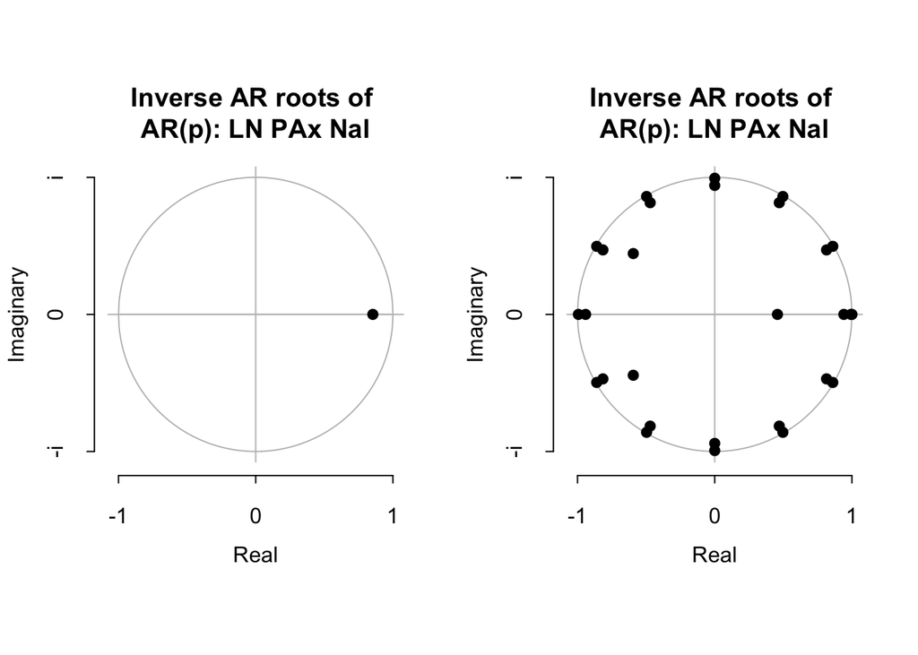

```r
par(mfrow=c(1,2))
plot.armaroots(arroots(SARIMA_Ex_DLPax_Nal),
               main="Inverse AR roots of \nAR(p): LN PAx Nal")
plot.armaroots(maroots(SARIMA_Ex_DLPax_Nal),
               main="Inverse AR roots of \nAR(p): LN PAx Nal")
```

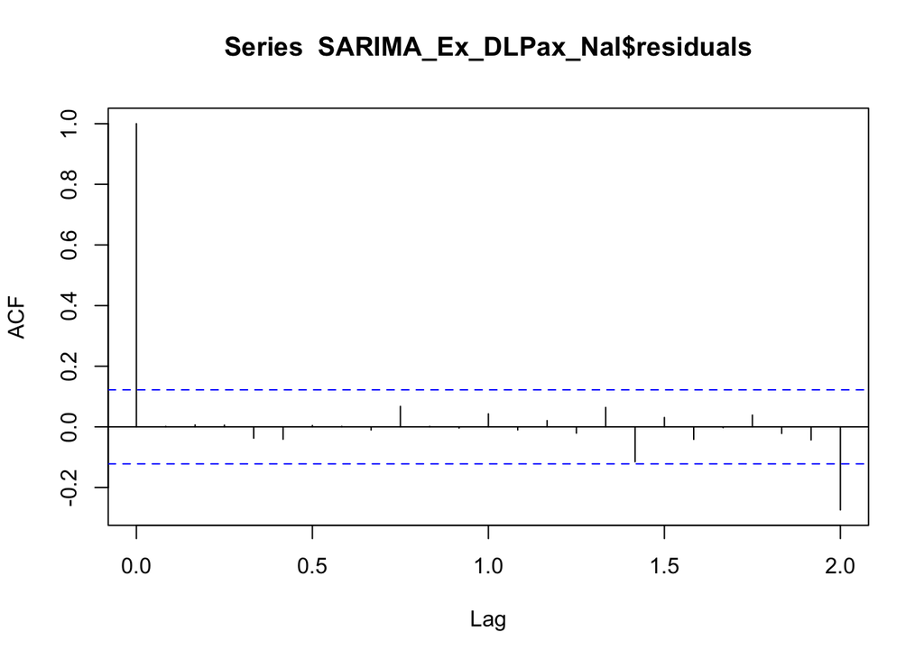

```r
par(mfrow=c(1,1))

acf(SARIMA_Ex_DLPax_Nal$residuals, na.action = na.pass)
```

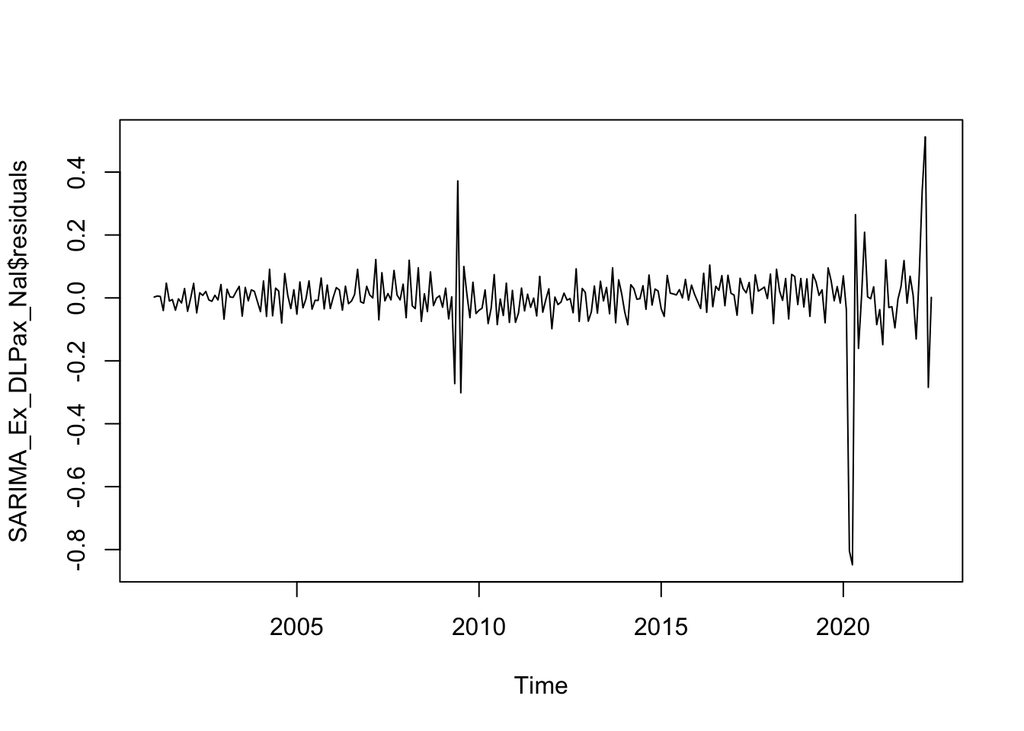

```r
plot(SARIMA_Ex_DLPax_Nal$residuals)
```

# ARIMA auto.arima():

```r
?auto.arima
#auto.arima
```

Implementación ARIMA:

```r
ARIMA_model = auto.arima(DLPax_Nal,
                         xreg = dumm_ARIMA,
                         seasonal = FALSE)

ARIMA_model
```

```
## Series: DLPax_Nal
## Regression with ARIMA(0,0,3) errors
##
## Coefficients:
##          ma1      ma2      ma3    D_Ene    D_Feb   D_Jul   D_Dic  D_Mar2020
##       -0.106  -0.0699  -0.5685  -0.0743  -0.0789  0.1926  0.0322    -0.3045
## s.e.   0.060   0.0571   0.0611   0.0176   0.0143  0.0188  0.0145     0.0837
##       D_Abr2020  D_Jun2020  D_Jul2020  D_Mar2021
##         -1.9728     0.9262     0.5589     0.4353
## s.e.     0.0839     0.0852     0.0873     0.0713
##
## sigma^2 = 0.007212:  log likelihood = 287.13
## AIC=-548.26   AICc=-546.84   BIC=-501.53
```

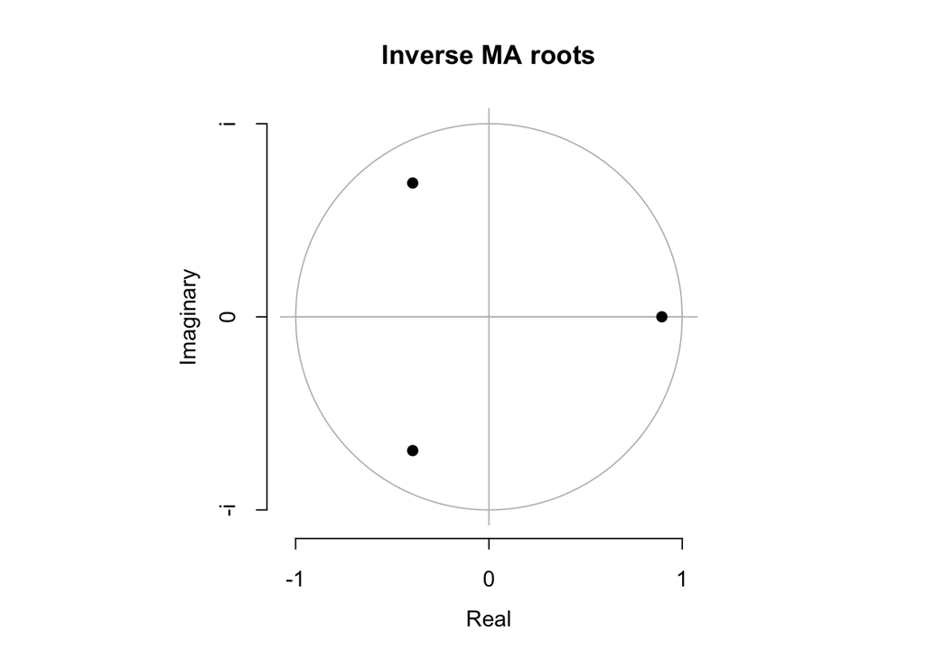

```r
#
plot(ARIMA_model)
```

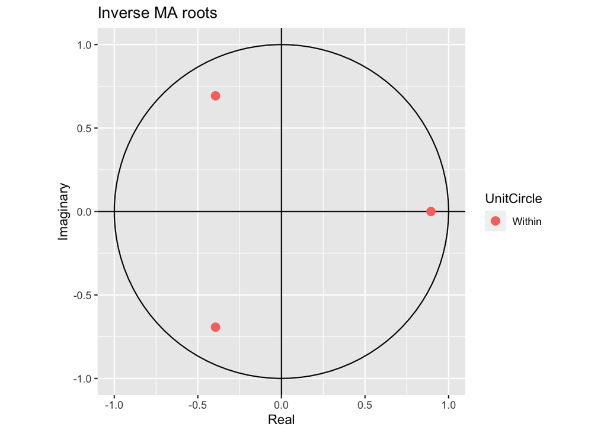

```r
autoplot(ARIMA_model)
```

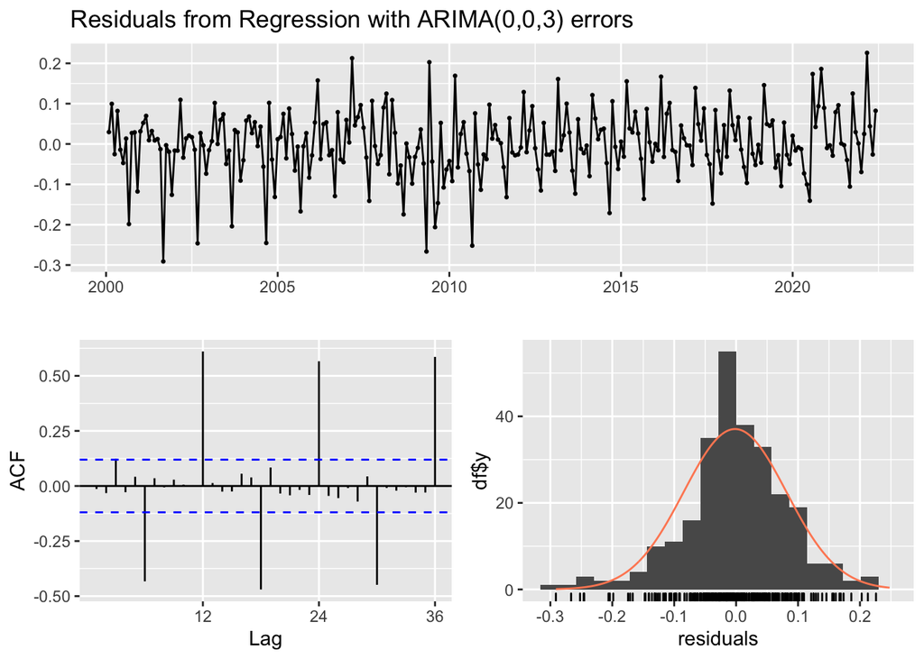

```
##
##  Ljung-Box test
##
## data:  Residuals from Regression with ARIMA(0,0,3) errors
## Q* = 328.27, df = 21, p-value < 2.2e-16
##
## Model df: 3.   Total lags used: 24
```

```r
checkresiduals(ARIMA_model)
```

Implementación SARIMA:

```r
SARIMA_model = auto.arima(DLPax_Nal_S, xreg =dumm_SARIMA)

SARIMA_model
```

```
## Series: DLPax_Nal_S
## Regression with ARIMA(2,0,0)(1,0,0)[12] errors
##
## Coefficients:
##          ar1      ar2     sar1    xreg1    xreg2   xreg3   xreg4    xreg5
##       0.5302  -0.4229  -0.3535  -0.1375  -1.3699  0.6695  0.3335  -0.4398
## s.e.  0.0726   0.0610   0.0741   0.1549   0.1743  0.1487  0.1340   0.1495
##
## sigma^2 = 0.0205:  log likelihood = 137.82
## AIC=-257.63   AICc=-256.9   BIC=-225.69
```

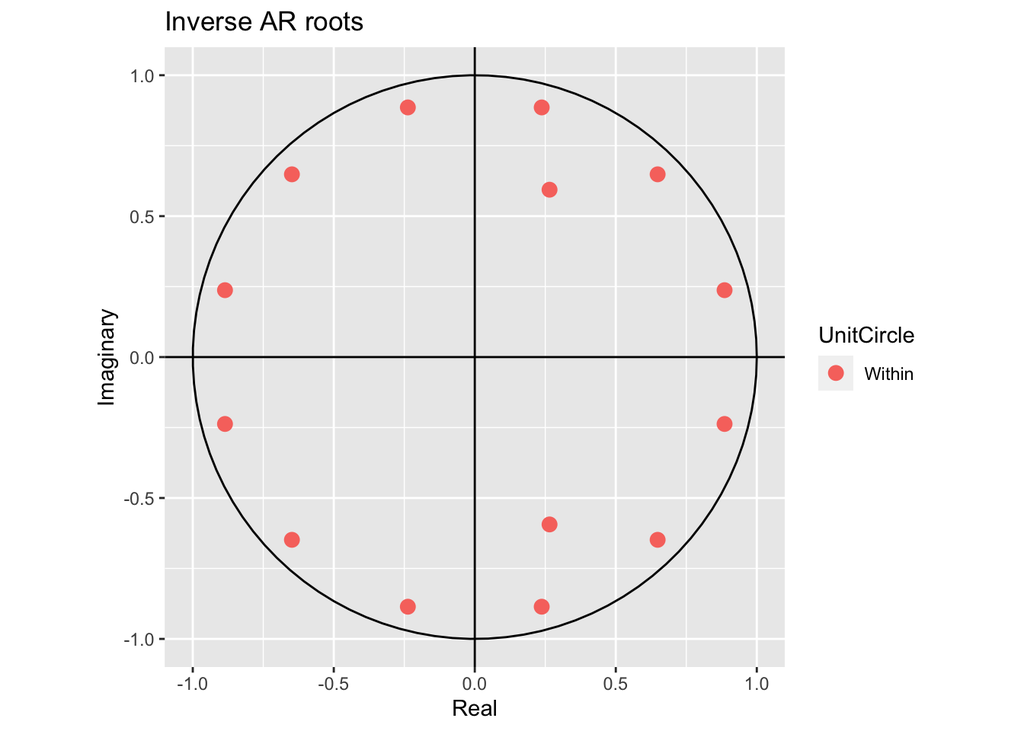

```r
autoplot(SARIMA_model)
```

```r
dumm_SARIMA <-cbind(D_Mar2020, D_Abr2020, D_Jun2020, D_Jul2020, D_Mar2021)

SARIMA_model2= auto.arima(LPax_Nal, xreg = dumm_SARIMA)

SARIMA_model2
```

```
## Series: LPax_Nal
## Regression with ARIMA(1,1,1)(2,0,0)[12] errors
##
## Coefficients:
##          ar1     ma1    sar1    sar2  D_Mar2020  D_Abr2020  D_Jun2020
##       0.3242  0.3642  0.3377  0.4546     0.2715    -0.6589     0.6375
## s.e.  0.0815  0.0706  0.0538  0.0569     0.0705     0.0744     0.0796
##       D_Jul2020  D_Mar2021
##          0.3781     0.1120
## s.e.     0.0747     0.0488
##
## sigma^2 = 0.01294:  log likelihood = 201.71
## AIC=-383.41   AICc=-382.56   BIC=-347.47
```

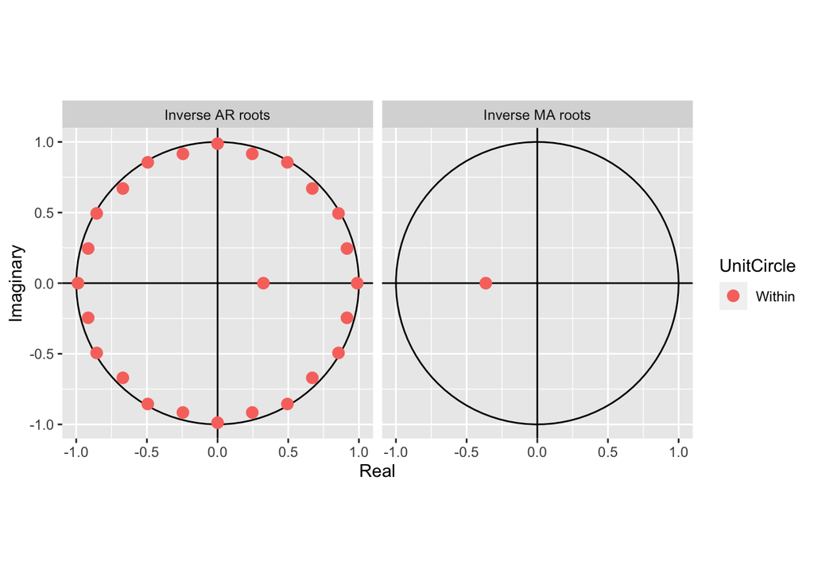

```r
autoplot(SARIMA_model2)
```

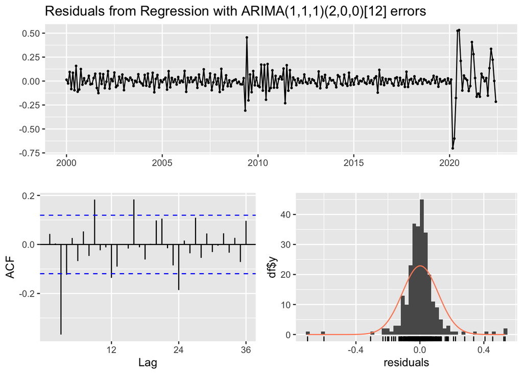

```
##
##  Ljung-Box test
##
## data:  Residuals from Regression with ARIMA(1,1,1)(2,0,0)[12] errors
## Q* = 91.633, df = 20, p-value = 3.836e-11
##
## Model df: 4.   Total lags used: 24
```

```r
checkresiduals(SARIMA_model2)
```

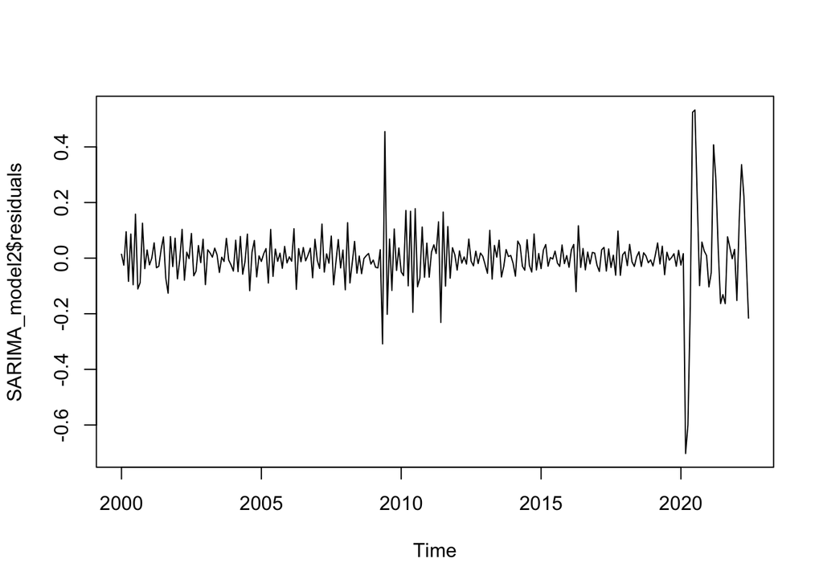

```r
plot(SARIMA_model2$residuals)
```

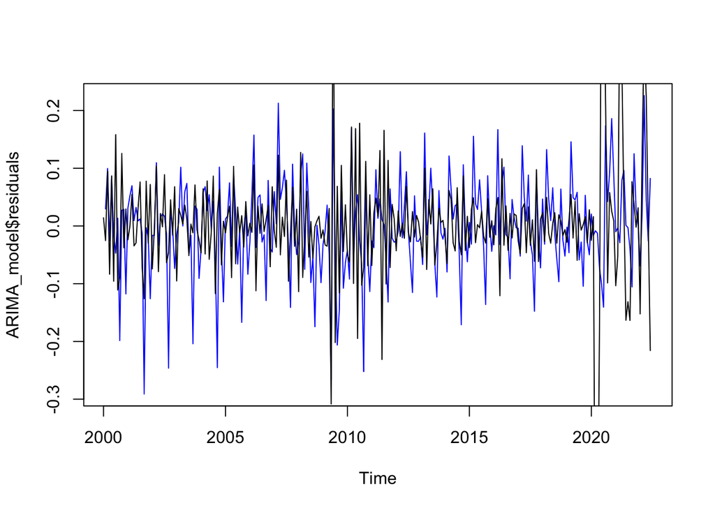

```r
plot(ARIMA_model$residuals, col = "blue")
lines(SARIMA_model2$residuals)
```

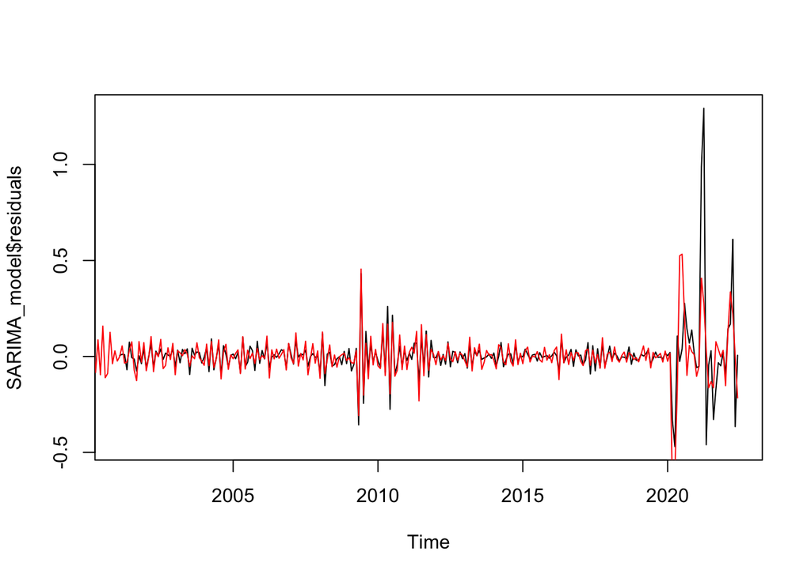

```r
plot(SARIMA_model$residuals)
lines(SARIMA_model2$residuals, col='red')
```